# Spotify Streaming in Germany Before and During the First Wave of the COVID-19 Pandemic:

Compared and Predicted

Kework K. Kalustian, M.A.

Music Dept., Max Planck Institute for Empirical Aesthetics, Frankfurt/Main, Germany

kework.kalustian@ae.mpg.de

# BACKGROUND

- The COVID-19 pandemic is an event with far-reaching consequences.
- Several negative consequences are observable.
- Yet, people tend to use more musical media during nationwide lockdowns (Fink et al., 2021).

# AIMS

> $RQ$: To what extent was music more streamed during the so-called first wave of the COVID-19 pandemic (March 11, 2020, until June 29, 2020) compared with the same period before the pandemic, and how is daily music listening predictable during the COVID-19 pandemic?

[figure not shown]

## HYPOTHESES

- H<sub>1</sub>: People tend to stream more of Germany’s daily top 200 Spotify charts during the COVID-19 pandemic than in a comparable reference period ($r ≥ .10$).
- H<sub>2</sub>: The stream counts of Germany’s daily top 200 Spotify charts during the COVID-19 pandemic are predictable based on daily stream counts from January 01, 2019, to March 10, 2020 ($MAPE ≤ 5$).

# METHODS

[figure not shown]

## DATA RETRIEVAL & CLEANING

- Web-scraping: Germany’s daily top 200 chart positions, song titles, their stream counts, and track IDs between January 01, 2019, and June 29, 2020 ($N = 109200$) from [Spotify’s website](https://spotifycharts.com/regional/de/daily/) ($546$ days $*$ $200$ chart positions).
- How?
- By using arguments of [Hadley Wickham’s](http://hadley.nz/) R package rvest for scraping websites within a simple `function` and by using his tidyverse):

Once the web scraping procedures was finished, the data looked like this:  
**Table 1**  
*First rows of the cleaned* `data.frame`.

| chart_position | title | artist | stream_count | date | n | songID |
| --- | --- | --- | --- | --- | --- | --- |
| 1 | Benzema | Capital Bra | 439742 | 2019-01-01 | 340 | 316 |
| 2 | HaifischNikez Allstars | LX, Maxwell, Bonez MC, Gzuz, Sa4 | 373845 | 2019-01-01 | 143 | 943 |
| 3 | Sweet but Psycho | Ava Max | 353209 | 2019-01-01 | 502 | 2302 |
| 4 | Baller los | MERO | 285326 | 2019-01-01 | 208 | 271 |
| 5 | Tausend Tattoos | Sido | 247009 | 2019-01-01 | 402 | 2328 |
| 6 | Lelele | Azet, Zuna | 240526 | 2019-01-01 | 127 | 1378 |

At first glance, the non-summarized daily stream counts per song are not symmetrically distributed (as expected):  
**Figure 1**  
*Histogram: Daily Stream Counts of Germany’s Daily top 200 Spotify Charts (Square Root-Scaling).*

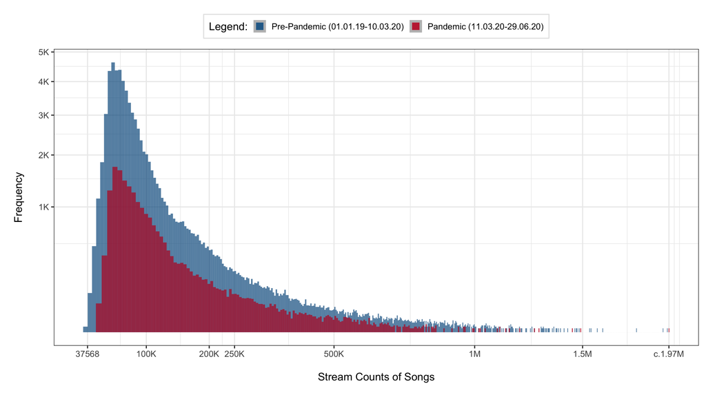

# DIFFERENCE TEST

Median summarized stream counts per day of the “pre-pandemic period” (March 11, to June 29, 2019; $n_{Pre-Pandemic} = 111$) and the “pandemic period” (March 11, to June 29, 2020; $n_{Pandemic} = 111$) compared:

- How?
- Via One-way paired Wilcoxon test (according to H<sub>1</sub>)

**Figure 2**  
*Connected Scatter plot: Daily Stream Counts of Germany’s Daily top 200 Spotify Charts per Period.*

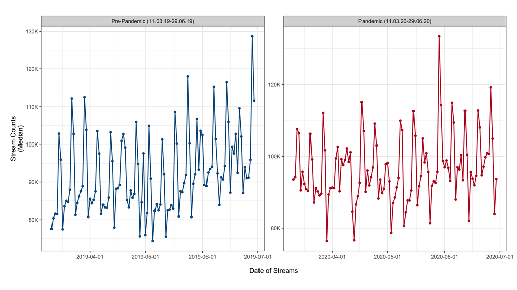

*Note.* $p < .001$, $z = -3.61$, $r = .343$, $CL = 95$%, $n = 111$

- People streamed more during the pandemic (moderate effect).